# Data on land and outside competences’ area

2022-03-14

This report presents very shortly the data located on land or outside of the competence area of tRFMOs. It is made for informative purposes for each RFMOs as well as for IRD while reviewing the Global Tuna Atlas.

The data presented as “on land” depends on the shape used for continents and oceans. It does not support the fact that the data is incorrect.

# Spatial distribution of the mislocated data on land

Those maps represent the value (in tons and in number of fish) of mislocated data for the period 1950-2020.

Is included the name of the RFMO providing data for the square located in lands.

[figure not shown]

# Distribution of data located on land

For several parameters, we analyze the distribution of data placed on land to uncover the features of this type of data.

## RFMO distribution

This graph represent the distribution of the providers of data located on land.

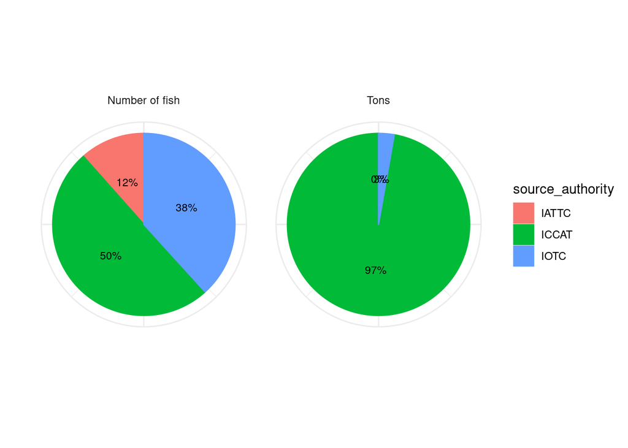

As we can see, most of the data located on land is coming from ICCAT and IOTC.

## Temporal distribution of the data located on land.

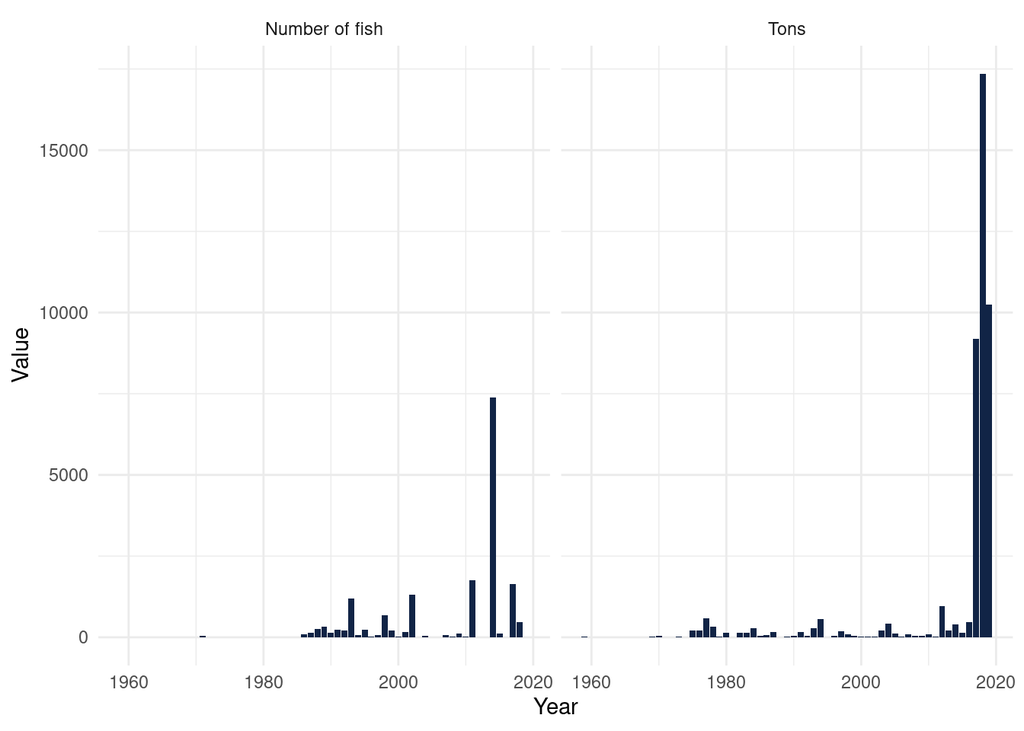

The data located on land seems to be a punctual issue for the data in fish. However in tons, the last 5 years seem to be problematic.

## General features of data on land.

### Fishingfleet in tons

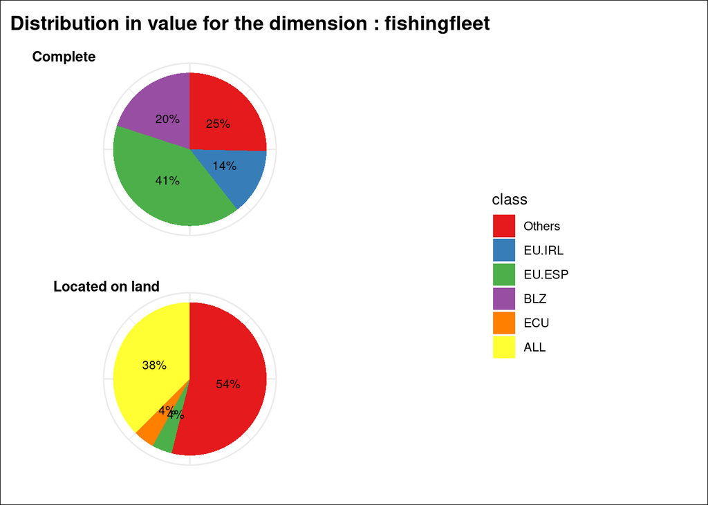

Ecuador (as well as data categorized as “Unkown” or “All”), represents a higher proportion of value on land than the usual value.

### Fishingfleet in numbers

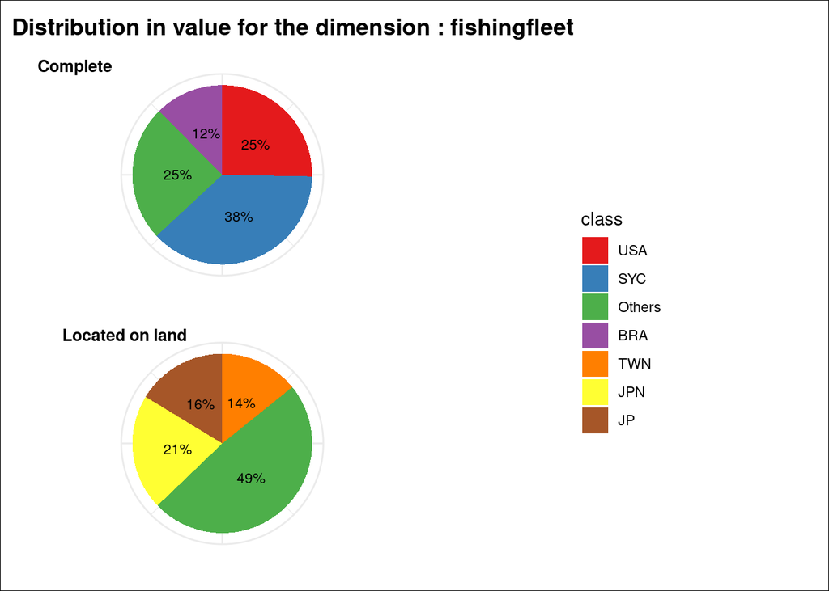

In number, Japan and Taïwan are locating more on land relatively compared to what they declare in Oceans.

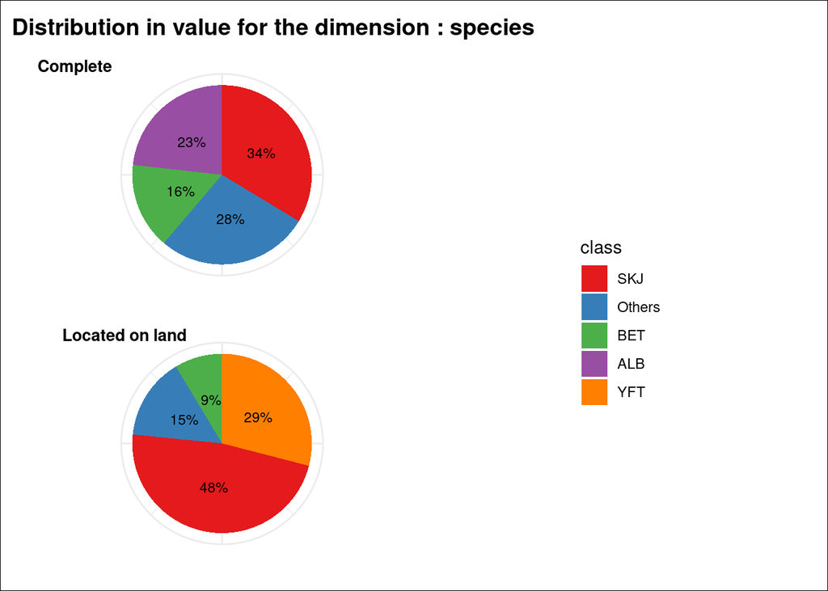

Yellowfin tuna is highly located on land compared to usual, as well as skipjack tuna.

The data placed on land represents (at the beginning of treatments in the GTA), 0.0014669 % in number and 0.0349407 % in tons.

# Data located outside the competence area of the tRFMO.

Some of the data is correctly placed in oceans, however it is placed by RFMO in area which does not correspond to the competence zone of the source authority.

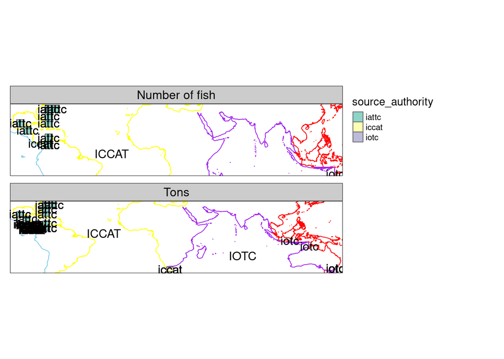

As we can see, some of those areas correspond to cwp squares at the border of the competence zone. However, some of data of the IATTC is actually placed really far from the competence zone.

How the data outside the competence zone should be handled ?